```python
import pandas as pd
import openpyxl
import matplotlib.pyplot as plt
```

# Analiza zmian sektora bankowego w latach 2010-2024

**Joanna Pokora**

## Wstęp

Celem raportu jest analiza zmian liczby banków, liczby oddziałów oraz struktury zatrudnienia w sektorze bankowym od roku 2010 do 2024. Zostanie ona przeprowadzona na podstawie danych liczbowych zebranych przez Komisję Nadzoru Finansowego.

## Dane

Użyte w raporcie liczby pochodzą ze strony Komisji Nadzoru Finansowego. Zostały tam zebrane dane miesięczne, od grudnia 2009 roku aż do grudnia 2024 roku. Ponieważ jednak interesuje nas ujęcie roczne, z analizy wyłączamy rok 2009, o którym informacje pochodzą tylko z jednego miesiąca, oraz uśredniamy wartości w każdym roku.

W raporcie wykorzystane zostaną informacje o

- liczbie krajowych banków komercyjnych, banków spółdzielczych oraz oddziałów instytucji kredytowych,
- liczbie oddziałów, filii, ekspozytur i innych placówek obsługi klienta a także przedstawicielstw banków (w tym w kraju i za granicą),
- całkowitej liczbie osób zatrudnionych w sektorze bankowym, liczbie osób zatrudnionych w centrali oraz w kraju i za granicą.

Aby móc poprawnie interpretować wyniki, wprowadźmy następujące definicje.

- Krajowy bank komercyjny - bank krajowy zorganizowany w formie spółki akcyjnej, banku państwowego, oddziału instytucji kredytowej ([Główny Urząd Statystyczny](https://stat.gov.pl/metainformacje/slownik-pojec/pojecia-stosowane-w-statystyce-publicznej/1575,pojecie.html)).
- Bank spółdzielczy - instytucja finansowa o lokalnym charakterze, działająca na zasadach spółdzielczych, gdzie każdy udziałowiec ma równe prawo głosu, niezależnie od liczby posiadanych udziałów („jeden udziałowiec = jeden głos”). W przeciwieństwie do banków funkcjonujących w formie spółki akcyjnej, bank spółdzielczy nie dąży do maksymalizacji zysków, lecz do ich optymalizacji, aby realizować nadrzędny cel, jakim jest wspieranie swoich członków i społeczności lokalnej ([Krajowy Związek Banków Spółdzielczych](https://kzbs.pl/charakterystyka.html).
- Instytucja kredytowa - przedsiębiorstwo, którego działalność polega na przyjmowaniu od ludności depozytów lub innych środków podlegających zwrotowi oraz na udzielaniu kredytów na własny rachunek ([INFOR.pl](https://www.infor.pl/prawo/encyklopedia-prawa/i/296383,instytucja-kredytowa.html)).

```python
data = pd.read_excel("/Users/2fanstupaka/Desktop/magisterka/bankowosc/banks_data.xlsx", header = [1], engine = "openpyxl")
```

```python
data = data.iloc[1:].copy()
```

```python
data["Year"] = data["Data"].dt.year
```

```python
del data["Data"]
```

```python
year_sum = data.groupby("Year").mean().reset_index()
```

## Wyniki

Na pierwszym wykresie przedstawione zostały zmiany liczby krajowych banków komercyjnych.

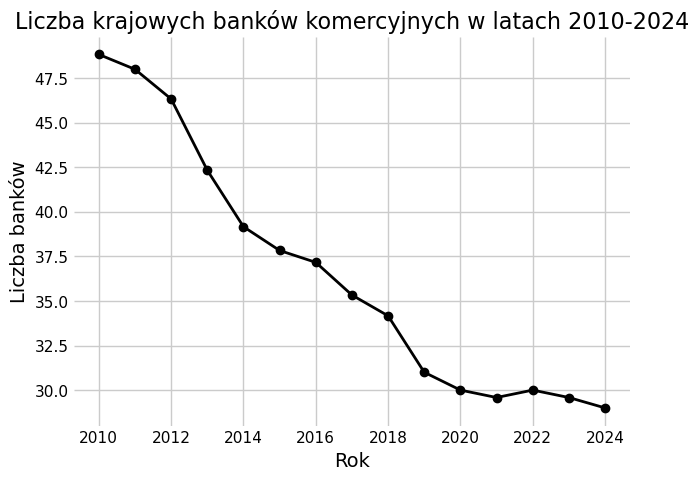

```python
plt.style.use("fivethirtyeight")

plt.plot(year_sum["Year"], year_sum["Liczba krajowych banków komercyjnych"], marker='o', linestyle='-', color='black', linewidth = 2)

plt.title("Liczba krajowych banków komercyjnych w latach 2010-2024", fontsize = 16)
plt.xlabel("Rok", fontsize = 14)
plt.ylabel("Liczba banków", fontsize = 14)

plt.tick_params(axis='both', which='major', labelsize=11)

for ax in plt.gcf().get_axes():
    ax.set_facecolor("white")
    for spine in ax.spines.values():
        spine.set_visible(False)

plt.gcf().set_facecolor("white")

plt.show()
```

Liczba banków komercyjnych malała z roku na rok, oprócz roku 2022, kiedy nieznacznie wzrosła. Największe spadki wystąpiły w 2013, 2014 oraz 2019 roku. Pomiędzy latami 2010 a 2019 średnia liczba banków komercyjnych spadła o prawie 18. Mogło być to następstwo globalnego kryzysu finansowego z 2008 roku oraz coraz bardziej rygorystycznych przepisów. Po 2019 roku liczba banków zaczęłą być natomiast stabilniejsza.

Kolejny wykres przedstawia zmianę liczby banków spółdzielczych.

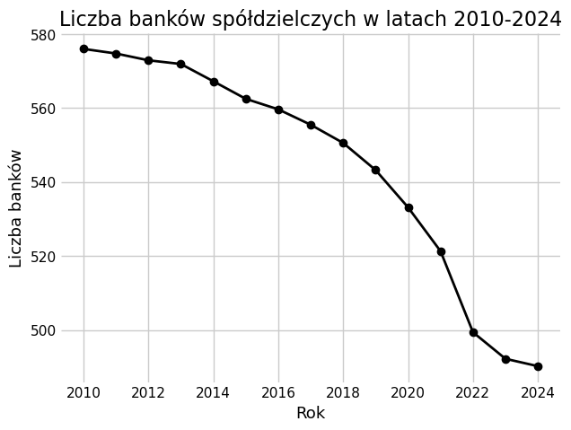

```python
plt.style.use("fivethirtyeight")

plt.plot(year_sum["Year"], year_sum["Liczba banków spółdzielczych"], marker='o', linestyle='-', color='black', linewidth = 2)

plt.title("Liczba banków spółdzielczych w latach 2010-2024", fontsize = 16)
plt.xlabel("Rok", fontsize = 13)
plt.ylabel("Liczba banków", fontsize = 13)

plt.tick_params(axis='both', which='major', labelsize=11)

for ax in plt.gcf().get_axes():
    ax.set_facecolor("white")
    for spine in ax.spines.values():
        spine.set_visible(False)

plt.gcf().set_facecolor("white")

plt.show()
```

Liczba banków spółdzielczych również spadała z każdym rokiem, jednak wolniej niż liczba banków komercyjnych. Trend spadkowy przyspieszył od 2019, a pomiędzy 2021 a 2022 rokiem zlikwidowano prawie 22 banki. Mogło być to spowodowane trwającą w tamtym czasie pandemią oraz digitalizją. Po tym spadku liczba banków spółdzielczych wydaje się być bardziej ustabilizowana, co może być związane z końcem pandemii oraz ugrunowaną pozycją wciąż działających banków.

Kolejny wykres obrazuje zmianę liczby oddziałów instytucji kredytowych w latach 2010-2024.

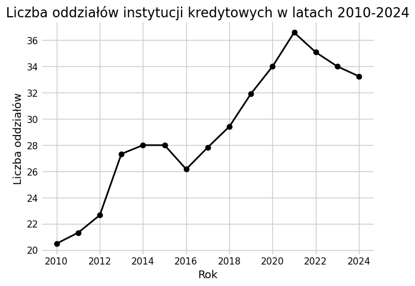

```python
plt.style.use("fivethirtyeight")

plt.plot(year_sum["Year"], year_sum["Liczba oddziałów instytucji kredytowych"], marker='o', linestyle='-', color='black', linewidth = 2)

plt.title("Liczba oddziałów instytucji kredytowych w latach 2010-2024", fontsize = 16)
plt.xlabel("Rok", fontsize = 13)
plt.ylabel("Liczba oddziałów", fontsize = 13)

plt.tick_params(axis='both', which='major', labelsize=11)

for ax in plt.gcf().get_axes():
    ax.set_facecolor("white")
    for spine in ax.spines.values():
        spine.set_visible(False)

plt.gcf().set_facecolor("white")

plt.show()
```

Wzrost liczby oddziałów nastąpił w latach 2010-2013 oraz 2016-2021, natomiast największy między rokiem 2012 a 2013. W roku 2012 nastąpiło zaostrzenie polityki kredytowej, wynikające z wdrożenia zmian w zakresie procedur oceny zdolności kredytowej, co na pewno wpłynęło na zmniejszony wzrost liczby oddziałów po 2013 roku, a nawet ich spadek w 2016 roku. W 2022 roku nastąpił natomiast związany z pandemią wzrost stóp procentowych w Polsce, co zmniejszyło popyt na kredyty. W efekcie, od tego roku również obserwowany jest spadek liczby oddziałów. Na zmniejszenie liczby fizycznych placówek może również wpływać postępująca digitalizacja oraz ograniczanie kosztów.

Na poniższym wykresie przedstawione zostały zmiany liczby oddziałów bankowych, w tym w kraju i za granicą.

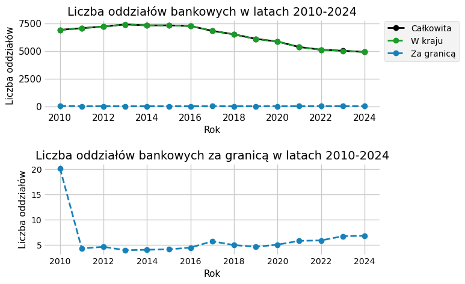

```python
plt.style.use("fivethirtyeight")

plt.subplots_adjust(hspace=0.6)

plt.subplot(211)

plt.plot(year_sum["Year"], year_sum["Liczba oddziałów"], marker='o', linestyle='-', color='black', label = "Całkowita", linewidth = 2)
plt.plot(year_sum["Year"], year_sum["   W kraju"], marker='o', linestyle='--', color='#189d27', label = "W kraju", linewidth = 2)
plt.plot(year_sum["Year"], year_sum["   Za granicą"], marker='o', linestyle='--', color='#1682b9', label = "Za granicą", linewidth = 2)

plt.title("Liczba oddziałów bankowych w latach 2010-2024", fontsize = 14)
plt.xlabel("Rok", fontsize = 11)
plt.ylabel("Liczba oddziałów", fontsize = 11)

plt.tick_params(axis='both', which='major', labelsize=11)

plt.legend(fontsize = 10, frameon = True, loc = "lower right", bbox_to_anchor=(1.25, 0.5))

plt.subplot(212)

plt.plot(year_sum["Year"], year_sum["   Za granicą"], marker='o', linestyle='--', color='#1682b9', label = "Za granicą", linewidth = 2)

plt.title("Liczba oddziałów bankowych za granicą w latach 2010-2024", fontsize = 14)
plt.xlabel("Rok", fontsize = 11)
plt.ylabel("Liczba oddziałów", fontsize = 11)

plt.tick_params(axis='both', which='major', labelsize=10)

for ax in plt.gcf().get_axes():
    ax.set_facecolor("white")
    for spine in ax.spines.values():
        spine.set_visible(False)

plt.gcf().set_facecolor("white")

plt.show()
```

Całkowita liczba oddziałów bankowych rosła przed rokiem 2013. Następnie na parę lat ustabilizowała się, aby potem zacząć wyraźnie maleć od 2017 roku i ponownie ustabilizować się po 2022 roku. Obserwowany trens spadkowy może być związany z digitalizacją oraz rosnącymi kosztami utrzymania oddziałów.

Za granicą, wyraźny spadek liczby oddziałów wystąpił w 2011 roku. Mogło to być następstwo globalnego kryzysu finansowego, zapoczątkowanego zapaścią na rynku pożyczek hipotecznych wysokiego ryzyka w Stanach Zjednoczonych. Jednocześnie, w tym okresie nie wystąpił spadek liczby oddziałów w kraju, co może być wytłumaczone faktem, że kryzys ten wpłynął na Polskę w znacznie mniejszym stopniu niż na inne kraje. Po 2011 roku liczba oddziałów bankowych za granicą ustabilizowała się, a w ostatnich latach można zaobserwować nieznaczny trend wzrostowy.

Następny wykres obrazuje zmiany liczby filii, ekspozytur i innych placówek obsługi klienta, w tym w kraju i za granicą.

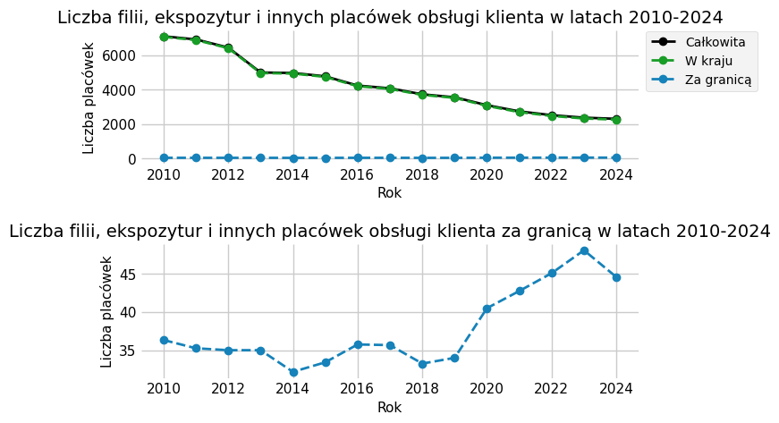

```python
plt.style.use("fivethirtyeight")

plt.subplots_adjust(hspace=0.6)

plt.subplot(211)

plt.plot(year_sum["Year"], year_sum["Liczba filii, ekspozytur i innych placówek obsługi klienta"], marker='o', linestyle='-', color='black', label = "Całkowita", linewidth = 2)
plt.plot(year_sum["Year"], year_sum["   W kraju2"], marker='o', linestyle='--', color='#189d27', label = "W kraju", linewidth = 2)
plt.plot(year_sum["Year"], year_sum["   Za granicą3"], marker='o', linestyle='--', color='#1682b9', label = "Za granicą", linewidth = 2)

plt.title("Liczba filii, ekspozytur i innych placówek obsługi klienta w latach 2010-2024", fontsize = 14)
plt.xlabel("Rok", fontsize = 11)
plt.ylabel("Liczba placówek", fontsize = 11)

plt.tick_params(axis='both', which='major', labelsize=11)

plt.legend(fontsize = 10, frameon = True, loc = "lower right", bbox_to_anchor=(1.25, 0.5))

plt.subplot(212)

plt.plot(year_sum["Year"], year_sum["   Za granicą3"], marker='o', linestyle='--', color='#1682b9', label = "Za granicą", linewidth = 2)

plt.title("Liczba filii, ekspozytur i innych placówek obsługi klienta za granicą w latach 2010-2024", fontsize = 14)
plt.xlabel("Rok", fontsize = 11)
plt.ylabel("Liczba placówek", fontsize = 11)

plt.tick_params(axis='both', which='major', labelsize=11)

for ax in plt.gcf().get_axes():
    ax.set_facecolor("white")
    for spine in ax.spines.values():
        spine.set_visible(False)

plt.gcf().set_facecolor("white")

plt.show()
```

Zarówno całkowita liczba placówek jak i ich liczba w kraju spadała z roku na rok, szybciej niż liczba oddziałów. Szczególnie wyraźny spadek nastąpił w 2013 roku. Mogło być to związane z postępującym przeniesiem sektora bankowego do przestrzeni internetu, co jest wygodniejsze dla klientów oraz zmniejsza koszty utrzymania placówek.

Inaczej wygląda to w przypadku zagranicznych placówek obługi klienta. Do 2019 roku ich liczba utrzymywała się na podobnym poziomie z nieznacznymi zmianami, a następnie zaczęła rosnąć, osiągając szczyt w 2023 roku. Zestawiając powyższy wykres z poprzednim, przedstawiającym zmiany liczby oddziałów za granicą, dostrzec można rozwój polskich instytucji bankowych za granicą.

Na poniższym wykresie przedstawione zostały liczby przedstawicielstw w latach 2010-2024.

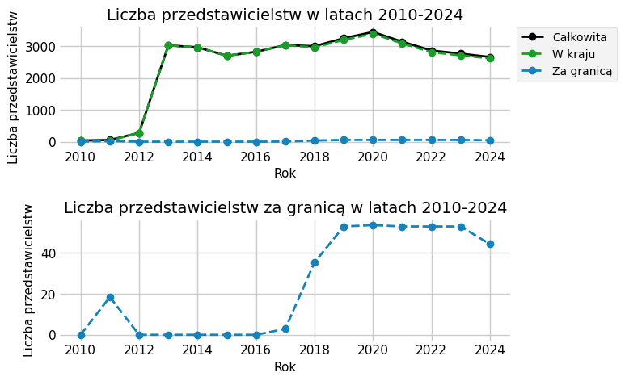

```python
plt.style.use("fivethirtyeight")

plt.subplots_adjust(hspace=0.6)

plt.subplot(211)

plt.plot(year_sum["Year"], year_sum["Liczba przedstawicielstw"], marker='o', linestyle='-', color='black', label = "Całkowita", linewidth = 2)
plt.plot(year_sum["Year"], year_sum["   W kraju4"], marker='o', linestyle='--', color='#189d27', label = "W kraju", linewidth = 2)
plt.plot(year_sum["Year"], year_sum["   Za granicą5"], marker='o', linestyle='--', color='#1682b9', label = "Za granicą", linewidth = 2)

plt.title("Liczba przedstawicielstw w latach 2010-2024", fontsize = 14)
plt.xlabel("Rok", fontsize = 11)
plt.ylabel("Liczba przedstawicielstw", fontsize = 11)

plt.tick_params(axis='both', which='major', labelsize=11)

plt.legend(fontsize = 10, frameon = True, loc = "lower right", bbox_to_anchor=(1.25, 0.5))

plt.subplot(212)

plt.plot(year_sum["Year"], year_sum["   Za granicą5"], marker='o', linestyle='--', color='#1682b9', label = "Za granicą", linewidth = 2)

plt.title("Liczba przedstawicielstw za granicą w latach 2010-2024", fontsize = 14)
plt.xlabel("Rok", fontsize = 11)
plt.ylabel("Liczba przedstawicielstw", fontsize = 11)

plt.tick_params(axis='both', which='major', labelsize=11)

for ax in plt.gcf().get_axes():
    ax.set_facecolor("white")
    for spine in ax.spines.values():
        spine.set_visible(False)

plt.gcf().set_facecolor("white")

plt.show()
```

W 2013 roku nastąpił duży wzrost liczby przedstawicielstw w kraju. Po tym roku ich liczba była dosyć stabilna aż do 2020 roku, w którym osiągnęła szczyt a następnie zaczęła spadać. Był to okres pandemii, co może stanowić jedną z możliwych przyczyn takiego zachowania.

Za granicą liczba przedstawicielstw była równa 0 aż do 2016 roku, poza rokiem 2011, w którym wynosiła około 18. W kolejnych latach wzrosła ona gwałtownie, a następnie ustabilizowała się i nieznacznie spadła w 2024 roku. Odpowiada to trendom na poprzednich wykresach, wskazującym na większą ekspansję za granicą.

Kolejne wykresy przedstawiając całkowitą liczbę osób zatrudnionych w sektorze bankowym oraz zatrudnienie w centrali, w kraju i za granicą.

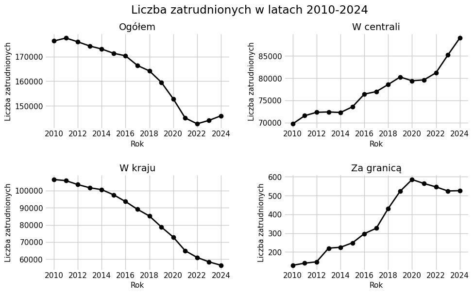

```python
plt.style.use("fivethirtyeight")

plt.figure(figsize=(10, 6))

plt.subplots_adjust(hspace=0.5, wspace = 0.3)

plt.subplot(2,2,1)

plt.plot(year_sum["Year"], year_sum["Liczba zatrudnionych"], marker='o', linestyle='-', color='black', linewidth = 2)

plt.title("Ogółem", fontsize = 14)
plt.xlabel("Rok", fontsize = 11)
plt.ylabel("Liczba zatrudnionych", fontsize = 11)

plt.tick_params(axis='both', which='major', labelsize=11)

for ax in plt.gcf().get_axes():
    ax.set_facecolor("white")
    for spine in ax.spines.values():
        spine.set_visible(False)

plt.gcf().set_facecolor("white")

plt.subplot(2,2,2)

plt.plot(year_sum["Year"], year_sum["   W centrali"], marker='o', linestyle='-', color='black', label = "W centrali", linewidth = 2)

plt.title("W centrali", fontsize = 14)
plt.xlabel("Rok", fontsize = 11)
plt.ylabel("Liczba zatrudnionych", fontsize = 11)

plt.tick_params(axis='both', which='major', labelsize=11)

for ax in plt.gcf().get_axes():
    ax.set_facecolor("white")
    for spine in ax.spines.values():
        spine.set_visible(False)

plt.gcf().set_facecolor("white")

plt.subplot(2,2,3)

plt.plot(year_sum["Year"], year_sum["   W kraju6"], marker='o', linestyle='-', color='black', linewidth = 2)

plt.title("W kraju", fontsize = 14)
plt.xlabel("Rok", fontsize = 11)
plt.ylabel("Liczba zatrudnionych", fontsize = 11)

plt.tick_params(axis='both', which='major', labelsize=11)

for ax in plt.gcf().get_axes():
    ax.set_facecolor("white")
    for spine in ax.spines.values():
        spine.set_visible(False)

plt.gcf().set_facecolor("white")

plt.subplot(2,2,4)

plt.plot(year_sum["Year"], year_sum["   Za granicą7"], marker='o', linestyle='-', color='black', linewidth = 2)

plt.title("Za granicą", fontsize = 14)
plt.xlabel("Rok", fontsize = 11)
plt.ylabel("Liczba zatrudnionych", fontsize = 11)

plt.tick_params(axis='both', which='major', labelsize=11)

for ax in plt.gcf().get_axes():
    ax.set_facecolor("white")
    for spine in ax.spines.values():
        spine.set_visible(False)

plt.gcf().set_facecolor("white")

plt.gcf().suptitle("Liczba zatrudnionych w latach 2010-2024")

plt.show()
```

Całkowita liczba osób zatrudnionych w sektorze bankowym zmniejszała się w latach 2012-2022, a następnie urosła nieznacznie w 2023 oraz 2024 roku. Trend spadkowy był jednak wyraźny, ze szczególnie dużymi różnicami po 2018 roku. W wyniku tego, liczba zatrudnionych zmalała na przestrzeni analizowanych lat z ponad 176301 do blisko 146034.

Szczególny, niezmienny spadek zatrudnienia zaobserwowany jest dla zatrudnionych w kraju, co pokrywa się ze znacznym spadkiem liczby placówek obługi klienta oraz banków. Z kolei liczba osób zatrudnionych w centrali oraz za granicą wyraźnie wzrosła na przestrzeni lat. Szczególnie w pierwszym przypadku, w ostatnich latach wystąpił wzrost liczby zatrudnionych, który odpowiedzialny jest za nieznaczne zwiększenie liczby wszystkich zatrudnionych.

Za granicą, szczyt liczby zatrudnionych przypadł na 2020, a następnie zaczęła ona nieznacznie maleć. Trend widoczny na tym wykresie pokrywa się z zaobserwowanym wcześniej rozwojem placówek za granicą. Ponadto, największy spadek liczby zatrudnionych przypadł na okres pandemii, co wskazuje na występujące powiązanie.

## Podsumowanie

Na podstawie zmian liczby banków komercyjnych i spółdzielczych wnioskować można, że sytuacja sektora bankowego na przestrzeni lat nie była najlepsza. Wskazują na to również zmiany liczby oddziałów bankowych oraz placówek obsługi klienta. Jednymi z przyczyn takich trendów mogą być globalne kryzysy finansowe, pandemia oraz zaostrzenie przepisów. Jednocześnie zamykanie fizycznych placówek może być również następstwem postępującej cyfryzacji.

Liczba oddziałów instytucji kredytowych rosła aż do roku 2021, z małym spadkiem w 2016 roku. W kolejnych latach popyt na kredyty zmalał w związku z wyższymi stopami kredytowymi, co może mieć swoje odzwiercielenie w spadkowym trendzie po tym roku.

Za granicą, krajowy sektor bankowy wydaje się rozwijać w ostatnich latach, co wcześniej mogło być trudniejsze na przykład ze względu na kryzys finansowy w 2008 roku. Pomimo tego, liczba osób zatrudnionych za granicą rosła aż do rozpoczęcia pandemii, co może wskazywać na rozwój już istniejących placówek.

Liczba osób zatrudnionych w kraju spada z roku na rok, rośnie natomiast zatrudnienie w centrali, co przekłożyło się na wzrost liczby osób zatrudnionych ogółem w 2023 oraz 2024 roku. Pomimo tego, nastąpił znaczny spadek liczby zatrudnionych na przedziale lat 2010-2024, wynoszący ponad 30 267 osób.